# Mock_Jury

Lingyu Meng, Tom Stafford

2024-04-09

# Introduction

According to the recent study (Lilley, Willmott, and Mojtahedi 2023), rape myth beliefs appear to predispose juror judgments and decision-making even after group-deliberation. Using their data, we aim to show how deliberation moves people towards/award from judgements of guilt, and if this was a product of coming towards or away from the beliefs of the group they were in.

```r
dat <- read_sav("Domestic Rape Trial Data - Video Jury group data[1] (1).sav")
dat <- dat %>% # individual level data
  group_by(JP_No) %>%
  mutate(sum_VC1 = sum(VC1),
         sum_VC2 = sum(VC2)) %>%
  ungroup() %>%
  mutate(pre_obj_i = abs((sum_VC1 - VC1)/ 11 - VC1), # the deviation from other 11 joiries' mean
         post_obj_i = abs((sum_VC2 - VC2)/ 11 - VC2)) # the deviation from other 11 joiries' mean

pan_dat <- dat %>% # group level data
  group_by(JP_No) %>%
  summarise(pre_contro= sd(VC1), # Controversy
            post_contro = sd(VC2),
            VC1 = mean(VC1),
            VC2 = mean(VC2),
            AMMSA = mean(AMMSA))
```

# Figure

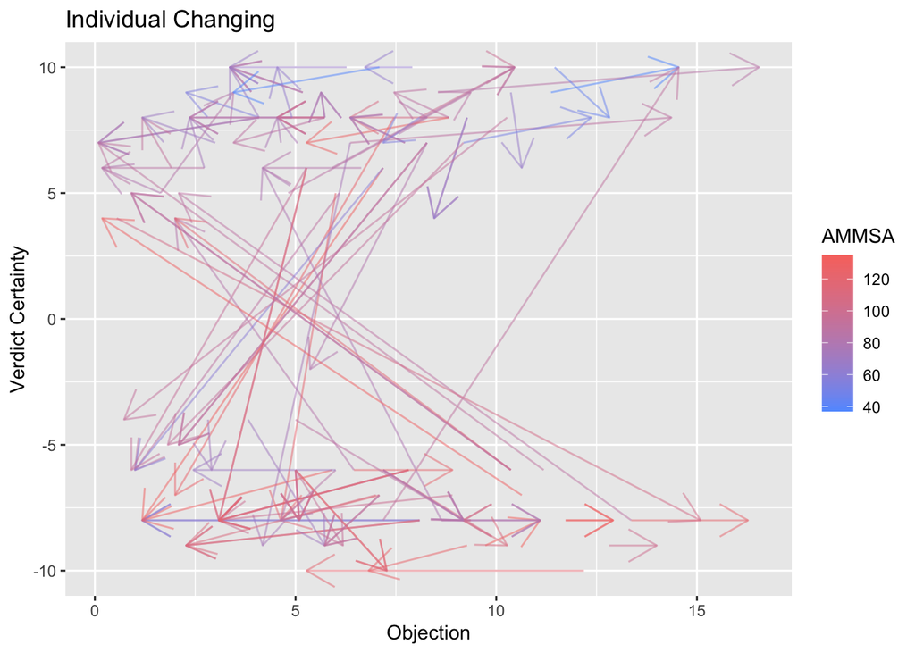

```r
fig1 <- ggplot(dat) +
  aes(x = pre_obj_i, y = VC1, xend = post_obj_i, yend = VC2, color = AMMSA) +
  geom_segment(arrow = arrow(),alpha = 0.5) +
  scale_color_gradient(low="#619CFF", high="#F8766D") +
  labs(title = "Individual Changing",
       x = "Objection",
       y = "Verdict Certainty")
fig1
```

figure 1: Individual Changing with shown AMMSA In this figure, the x-axis is individual objection, which is calculated by the absolute value of the difference between the individual’s score and the mean of other 11 juries’ scores. The y-axis is the verdict certainty. The color of the points represents the AMMSA.

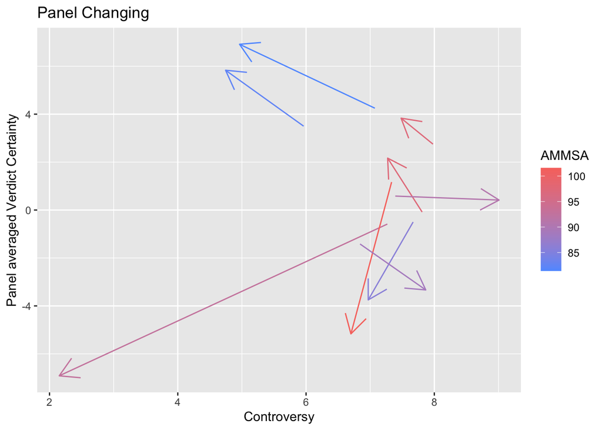

```r
fig2 <- ggplot(pan_dat) +
  aes(x = pre_contro, y = VC1, xend = post_contro, yend = VC2, color = AMMSA) +
  geom_segment(arrow = arrow()) +
  scale_color_gradient(low="#619CFF", high="#F8766D") +
  labs(title = "Panel Changing",
       x = "Controversy",
       y = "Panel averaged Verdict Certainty")
fig2
```

figure 2: Panel Changing with shown AMMSA In this figure, the x-axis is the controversy, which is calculated by the standard deviation of the 12 juries’ scores. The y-axis is the panel averaged verdict certainty. The color of the points represents the averaged AMMSA.

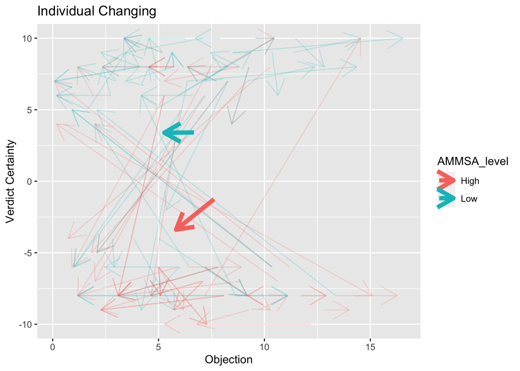

```r
# Using median segmentation, we aim to show how the AMMSA affects the change of the verdict certainty.
dat <- dat %>%
  mutate(AMMSA_level = ifelse(AMMSA > median(AMMSA), "High", "Low"))
dat_AMMSA <- dat %>%
  group_by(AMMSA_level) %>%
  summarise(pre_contro= mean(pre_obj_i), # Controversy
            post_contro = mean(post_obj_i),
            VC1 = mean(VC1),
            VC2 = mean(VC2))
# plot
fig3 <- ggplot(dat) +
  aes(x = pre_obj_i, y = VC1, xend = post_obj_i, yend = VC2, color = AMMSA_level) +
  geom_segment(arrow = arrow(),alpha = 0.2) +
  labs(title = "Individual Changing",
       x = "Objection",
       y = "Verdict Certainty")
fig3 + geom_segment(data = dat_AMMSA,
                    arrow = arrow(),
                    aes(x = pre_contro, y = VC1, xend = post_contro, yend = VC2, color = AMMSA_level),
                    lwd = 2)
```

# References

Lilley, Caroline, Dominic Willmott, and Dara Mojtahedi. 2023. “Juror Characteristics on Trial: Investigating How Psychopathic Traits, Rape Attitudes, Victimization Experiences, and Juror Demographics Influence Decision-Making in an Intimate Partner Rape Trial.” *Frontiers in Psychiatry* 13 (January): 1086026. https://doi.org/10.3389/fpsyt.2022.1086026.